# Informe de recurrencia

2022-09-11

## Recurrencia general

El siguiente análisis considera únicamente personas que registran matrícula inicial en el período que va de 2016 a 2022. Para cada año, se cuentan personas únicas que se han matriculado en alguna propuesta y estuvieron en condiciones de iniciar la cursada (destinatarios). Si en un año determinado una persona se matriculó pero ya registraba una matrícula en algún año anterior, se la considera *recurrente*, caso contrario, se la considera como una persona *nueva* en el instituto.

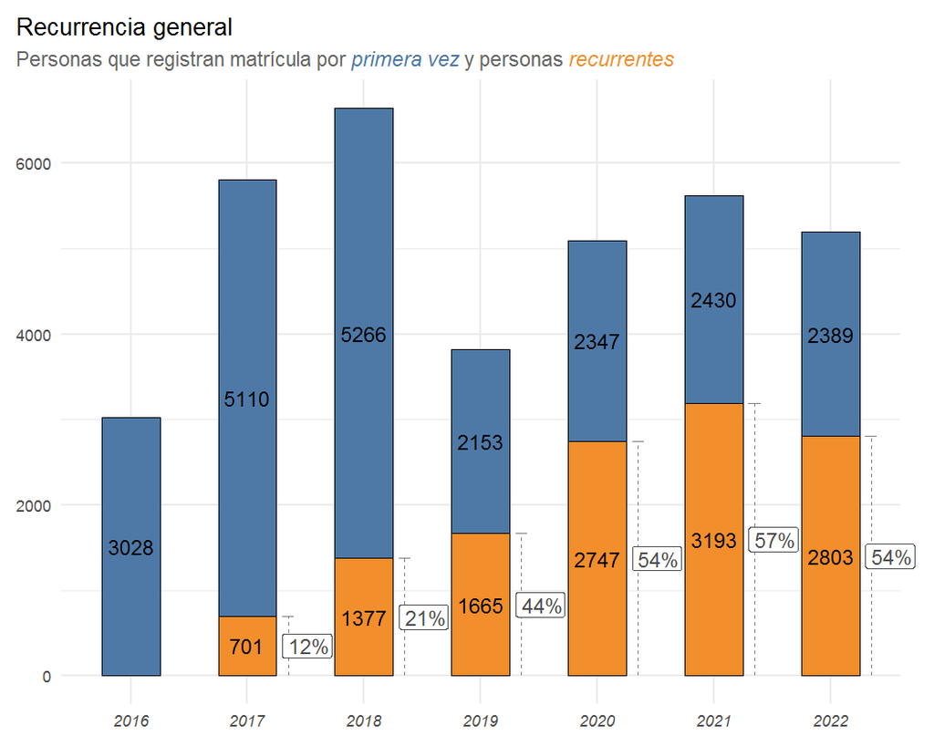

> A partir del 2019, cada 10 personas que se matriculan en propuestas, 5 son recurrentes, es decir, ya se han matriculado en al menos una propuesta formativa anteriormente. Dicho de otra forma, a partir del 2019, del total de matrículas iniciales, el 50% corresponde a personas recurrentes.

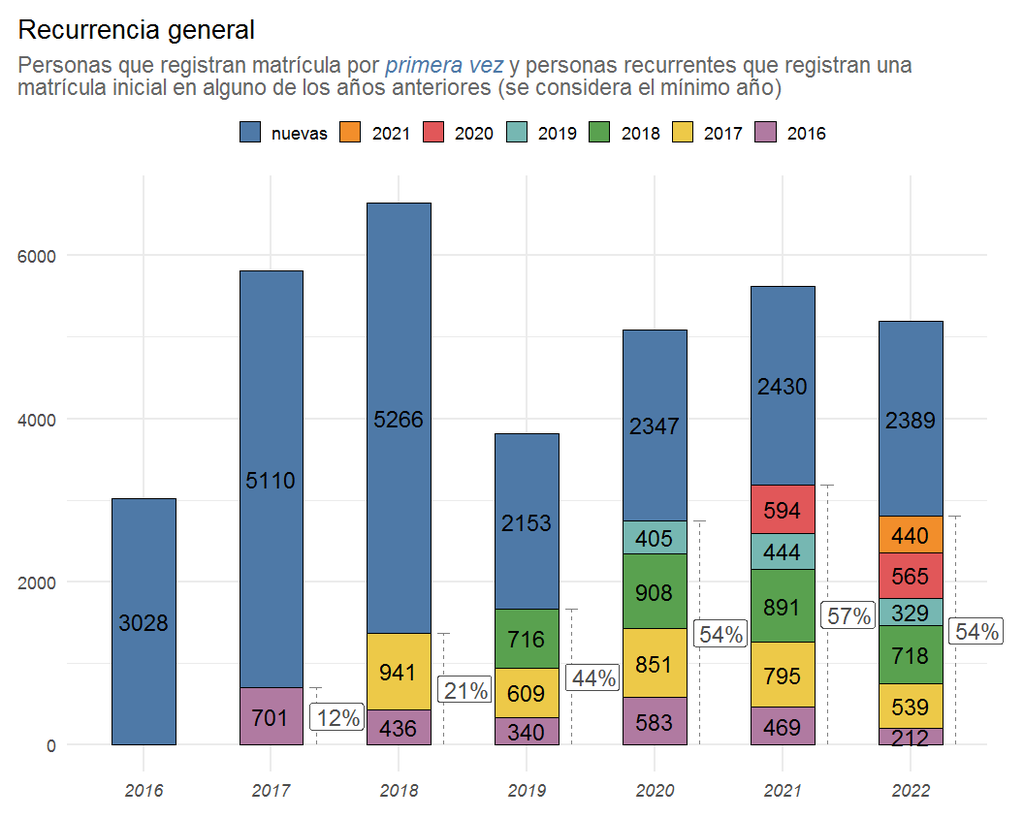

A continuación se realiza el mismo análisis pero al interior de cada grupo de propuestas (agrupaciones ad-hoc).

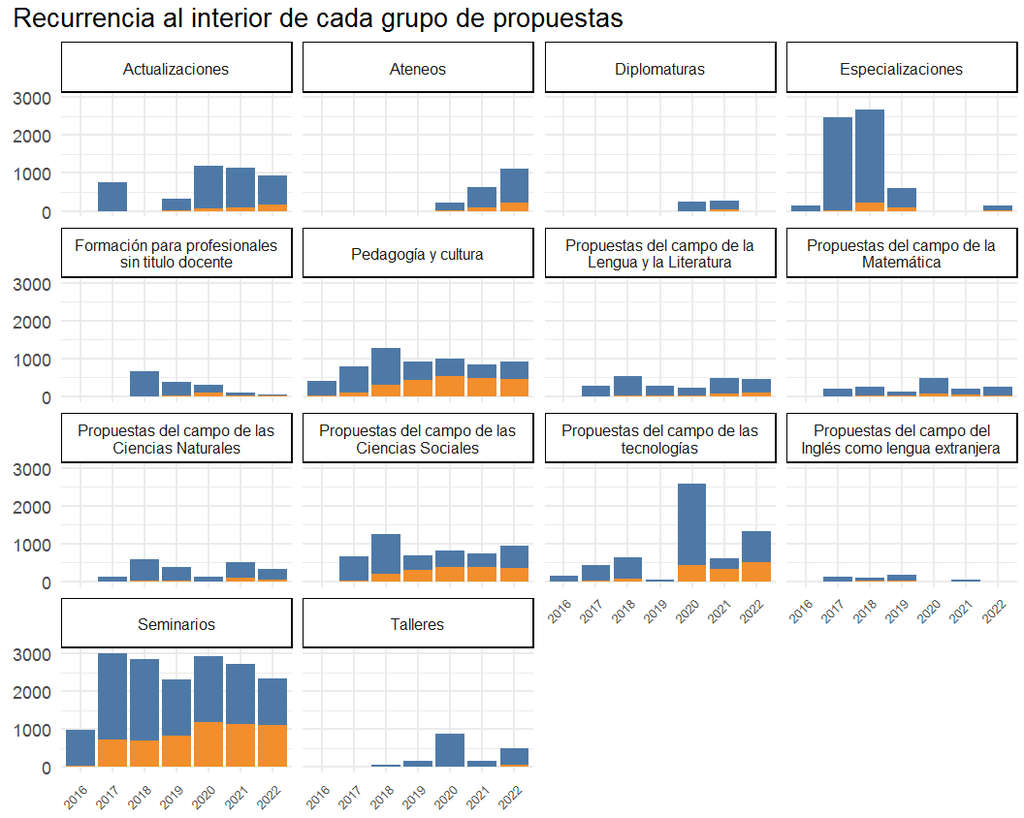

Algunas observaciones que pueden hacerse a partir de la visualización anterior:

- Los *Seminarios* mantienen una cantidad alta de personas a lo largo del tiempo y el porcentaje de personas recurrentes crece con el tiempo. Sin embargo, el mayor porcentaje de personas matriculadas en cada año corresponde a personas nuevas.
- Las personas que se matriculan en propuestas de *Pedagogía y Cultura* a partir del 2019 son mayormente recurrentes en propuestas pertenecientes a este grupo.
- En el año 2020 el grupo de *propuestas del campo de las tecnologías* tuvo un elevado número de personas (mayormente nuevas). Las propuestas con mayor número de personas matriculadas aceptadas fueron la *Actualización Académica Enseñar con Herramientas Digitales*, el *Taller la Clase en Pantuflas*, el *Seminario de Pensamiento Computacional* y el taller: *Dar clase con herramientas digitales.*

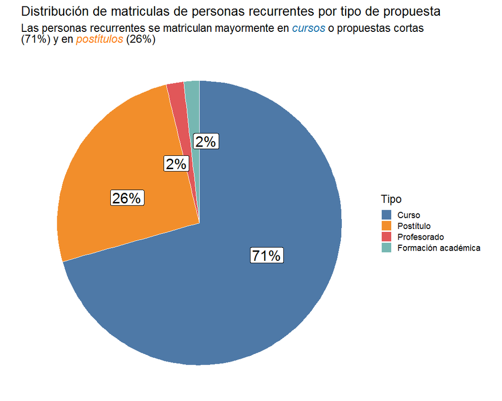

Como se observa en la gráfica anterior, las personas recurrentes se matriculan mayormente en cursos y esto se mantiene si agregamos la dimensión del año de matriculación.

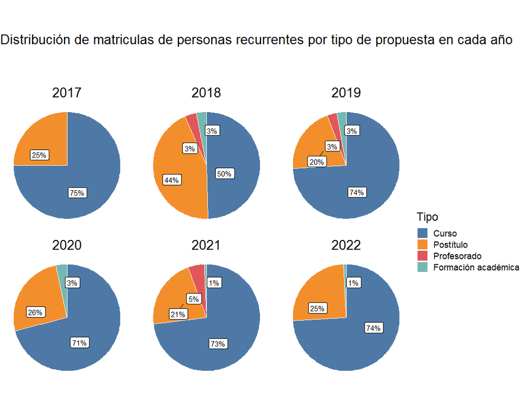